# Feature Importance in Neural Networks

- 01 Overview
- 02 Complete
  - Generating Data
  - Defining Model
  - Evaluating Model
  - Animated Bar Graph
  - Box Plot
  - Standard Deviation
  - Scatter Plots
  - Probability Density
  - Feature Importance
- 03 One Value
  - Box Plot
  - Probability Density
  - Feature Importance
- 04 Accuracy
  - Dataset 1 Results
  - Dataset 2 Results
  - Dataset 3 Results
- 05 Classification
  - Box Plot
  - Probability Density
  - Feature Importance
- 06 Titanic
  - Random Forest
  - Neural Network
  - Comparison

# Accuracy

In this example we will explore how accuracy effects the effectiveness of the methodolgy as accuracy decreases

```python
import math
import warnings

from typing import List, Dict
from statistics import mean, stdev
from random import randint, random

import pandas as pd
import tensorflow as tf
import matplotlib
import matplotlib.pyplot as plt
import numpy as np
from tensorflow.keras.optimizers import Adam
from scipy.stats import norm

warnings.filterwarnings("ignore")

matplotlib.rcParams["animation.embed_limit"] = 2**128
matplotlib.rcParams["figure.dpi"] = 300
```

## Generating data

The data used for this notebook follows the equation $y = mx + c$. To ensure replicable results as well as keeping the network's topology as simple as possible, the values for **m's** and **c's** are static whilst the values for **x's** are randomly generated. There is the addition of a **noise** column that is purely there as a target for the network to tune out.

In order to tweak the accuracy, we will generate three sets of data which will progressively reduce the accuracy of the model. This will be achieved by swapping out various values for **y's** with randomly selected values.

```python
samples = 5000
split = 100


def generate_random_values():
    return [randint(0, 50) * randint(0, 50) for _ in range(samples)]


ms = [2 for _ in range(samples)]
xs = generate_random_values()
cs = [50 for _ in range(samples)]

ys = []
for i in range(samples):
    y = ms[i] * xs[i] + cs[i]
    ys.append(y)
noise = [randint(0, 100) for _ in range(samples)]
```

### Dataset 1 - ~85% Accuracy

```python
random_indices = [randint(0, samples - 1) for _ in range(int(samples / 25))]
for i in random_indices:
        ys[i] = randint(min(ys), max(ys))


data = {"ms": ms, "xs": xs, "cs": cs, "noise": noise, "ys": ys}

df = pd.DataFrame(data=data)
train = df.iloc[split:]
test = df.iloc[:split]
```

```python
X_train_1 = train[["ms", "xs", "cs", "noise"]]
y_train_1 = train["ys"]
X_test_1 = test[["ms", "xs", "cs", "noise"]]
y_test_1 = test["ys"]
```

### Dataset 2 - ~70% Accuracy

```python
random_indices = [randint(0, samples - 1) for _ in range(int(samples / 10))]
for i in random_indices:
        ys[i] = randint(min(ys), max(ys))

data = {"ms": ms, "xs": xs, "cs": cs, "noise": noise, "ys": ys}

df = pd.DataFrame(data=data)
train = df.iloc[split:]
test = df.iloc[:split]
```

```python
X_train_2 = train[["ms", "xs", "cs", "noise"]]
y_train_2 = train["ys"]
X_test_2 = test[["ms", "xs", "cs", "noise"]]
y_test_2 = test["ys"]
```

```python
random_indices = [randint(0, samples - 1) for _ in range(int(samples / 5))]
for i in random_indices:
        ys[i] = randint(min(ys), max(ys))

data = {"ms": ms, "xs": xs, "cs": cs, "noise": noise, "ys": ys}

df = pd.DataFrame(data=data)
train = df.iloc[split:]
test = df.iloc[:split]
```

```python
X_train_3 = train[["ms", "xs", "cs", "noise"]]
y_train_3 = train["ys"]
X_test_3 = test[["ms", "xs", "cs", "noise"]]
y_test_3 = test["ys"]
```

```python
def create_history(columns: int, nodes: int) -> Dict:
    return {i:{j: [] for j in range(nodes)} for i in range(columns)}
```

## Models

```python
FIRST_LAYER = 4
```

### Dataset 1

```python
history_1 = create_history(len(X_train_1.columns), FIRST_LAYER)
```

```python
model_1 = tf.keras.Sequential()
model_1.add(tf.keras.layers.Dense(units=FIRST_LAYER, input_shape=[4]))
model_1.add(tf.keras.layers.Dense(units=1))
model_1.summary()
opt = Adam(0.01)
model_1.compile(optimizer=opt, loss="mean_squared_error")
```

```
Metal device set to: Apple M1 Max

systemMemory: 64.00 GB
maxCacheSize: 24.00 GB

Model: "sequential"
_________________________________________________________________
 Layer (type)                Output Shape              Param #
=================================================================
 dense (Dense)               (None, 4)                 20

 dense_1 (Dense)             (None, 1)                 5

=================================================================
Total params: 25
Trainable params: 25
Non-trainable params: 0
_________________________________________________________________
```

```python
for epoch in range(1, 301):
    print(f"RUNNING EPOCH {epoch}")
    hist = model_1.fit(X_train_1, y_train_1, epochs=1)
    all_weights = model_1.layers[0].get_weights()[0].tolist()
    for weights in range(len(all_weights)):
        for weight in range(len(all_weights[weights])):
            history_1[weights][weight].append(all_weights[weights][weight])
```

```
RUNNING EPOCH 1
```

### Dataset 2

```python
history_2 = create_history(len(X_train_2.columns), FIRST_LAYER)
```

```python
model_2 = tf.keras.Sequential()
model_2.add(tf.keras.layers.Dense(units=FIRST_LAYER, input_shape=[4]))
model_2.add(tf.keras.layers.Dense(units=1))
model_2.summary()
opt = Adam(0.01)
model_2.compile(optimizer=opt, loss="mean_squared_error")
```

```
Model: "sequential_1"
_________________________________________________________________
 Layer (type)                Output Shape              Param #
=================================================================
 dense_2 (Dense)             (None, 4)                 20

 dense_3 (Dense)             (None, 1)                 5

=================================================================
Total params: 25
Trainable params: 25
Non-trainable params: 0
_________________________________________________________________
```

```python
for epoch in range(1, 301):
    print(f"RUNNING EPOCH {epoch}")
    hist = model_2.fit(X_train_2, y_train_2, epochs=1)
    all_weights = model_2.layers[0].get_weights()[0].tolist()
    for weights in range(len(all_weights)):
        for weight in range(len(all_weights[weights])):
            history_2[weights][weight].append(all_weights[weights][weight])
```

### Dataset 3

```python
history_3 = create_history(len(X_train_3.columns), FIRST_LAYER)
```

```python
model_3 = tf.keras.Sequential()
model_3.add(tf.keras.layers.Dense(units=FIRST_LAYER, input_shape=[4]))
model_3.add(tf.keras.layers.Dense(units=1))
model_3.summary()
opt = Adam(0.01)
model_3.compile(optimizer=opt, loss="mean_squared_error")
```

```
Model: "sequential_2"
_________________________________________________________________
 Layer (type)                Output Shape              Param #
=================================================================
 dense_4 (Dense)             (None, 4)                 20

 dense_5 (Dense)             (None, 1)                 5

=================================================================
Total params: 25
Trainable params: 25
Non-trainable params: 0
_________________________________________________________________
```

```python
for epoch in range(1, 301):
    print(f"RUNNING EPOCH {epoch}")
    hist = model_3.fit(X_train_3, y_train_3, epochs=1)
    all_weights = model_3.layers[0].get_weights()[0].tolist()
    for weights in range(len(all_weights)):
        for weight in range(len(all_weights[weights])):
            history_3[weights][weight].append(all_weights[weights][weight])
```

## Evaluating Models

### Dataset 1

```python
res_ms = X_test_1["ms"].values.tolist()
res_xs = X_test_1["xs"].values.tolist()
res_cs = X_test_1["cs"].values.tolist()
res_noise = X_test_1["noise"].values.tolist()
res_pred = [
    round(i) for i in model_1.predict(X_test_1).flatten().tolist()
]
res = {
    "ms": res_ms,
    "xs": res_xs,
    "cs": res_cs,
    "noise": res_noise,
    "ys": y_test_1,
    "pred": res_pred
}

res = pd.DataFrame(res)
res
```

|  | ms | xs | cs | noise | ys | pred |
| --- | --- | --- | --- | --- | --- | --- |
| 0 | 2 | 0 | 50 | 9 | 50 | 131 |
| 1 | 2 | 1008 | 50 | 38 | 2066 | 2089 |
| 2 | 2 | 330 | 50 | 12 | 710 | 771 |
| 3 | 2 | 1363 | 50 | 8 | 2776 | 2769 |
| 4 | 2 | 1496 | 50 | 5 | 3042 | 3025 |
| ... | ... | ... | ... | ... | ... | ... |
| 95 | 2 | 470 | 50 | 50 | 990 | 1051 |
| 96 | 2 | 24 | 50 | 68 | 98 | 193 |
| 97 | 2 | 147 | 50 | 70 | 344 | 431 |
| 98 | 2 | 595 | 50 | 16 | 1240 | 1284 |
| 99 | 2 | 76 | 50 | 76 | 202 | 295 |

100 rows × 6 columns

```python
expected = list(res["ys"].values)
actual = list(res["pred"].values)
accuracies = []
for i in range(len(expected)):
    if expected[i] > actual[i]:
        accuracies.append((actual[i] / expected[i]) * 100)
    elif expected[i] < actual[i]:
        accuracies.append((expected[i] / actual[i]) * 100)
    else:
        accuracies.append(100)
print(f"Model 1 is correct to {round(mean(accuracies), 5)}%")
```

```
Model 1 is correct to 82.91462%
```

### Dataset 2

```python
res_ms = X_test_2["ms"].values.tolist()
res_xs = X_test_2["xs"].values.tolist()
res_cs = X_test_2["cs"].values.tolist()
res_noise = X_test_2["noise"].values.tolist()
res_pred = [
    round(i) for i in model_2.predict(X_test_2).flatten().tolist()
]
res = {
    "ms": res_ms,
    "xs": res_xs,
    "cs": res_cs,
    "noise": res_noise,
    "ys": y_test_2,
    "pred": res_pred
}

res = pd.DataFrame(res)
res
```

|  | ms | xs | cs | noise | ys | pred |
| --- | --- | --- | --- | --- | --- | --- |
| 0 | 2 | 0 | 50 | 9 | 50 | 356 |
| 1 | 2 | 1008 | 50 | 38 | 3651 | 2029 |
| 2 | 2 | 330 | 50 | 12 | 710 | 905 |
| 3 | 2 | 1363 | 50 | 8 | 2776 | 2626 |
| 4 | 2 | 1496 | 50 | 5 | 3042 | 2848 |
| ... | ... | ... | ... | ... | ... | ... |
| 95 | 2 | 470 | 50 | 50 | 990 | 1131 |
| 96 | 2 | 24 | 50 | 68 | 98 | 385 |
| 97 | 2 | 147 | 50 | 70 | 344 | 590 |
| 98 | 2 | 595 | 50 | 16 | 1363 | 1345 |
| 99 | 2 | 76 | 50 | 76 | 202 | 470 |

100 rows × 6 columns

```python
expected = list(res["ys"].values)
actual = list(res["pred"].values)
accuracies = []
for i in range(len(expected)):
    if expected[i] > actual[i]:
        accuracies.append((actual[i] / expected[i]) * 100)
    elif expected[i] < actual[i]:
        accuracies.append((expected[i] / actual[i]) * 100)
    else:
        accuracies.append(100)
print(f"Model 2 is correct to {round(mean(accuracies), 5)}%")
```

```
Model 2 is correct to 68.06047%
```

### Dataset 3

```python
res_ms = X_test_3["ms"].values.tolist()
res_xs = X_test_3["xs"].values.tolist()
res_cs = X_test_3["cs"].values.tolist()
res_noise = X_test_3["noise"].values.tolist()
res_pred = [
    round(i) for i in model_3.predict(X_test_3).flatten().tolist()
]
res = {
    "ms": res_ms,
    "xs": res_xs,
    "cs": res_cs,
    "noise": res_noise,
    "ys": y_test_3,
    "pred": res_pred
}

res = pd.DataFrame(res)
res
```

|  | ms | xs | cs | noise | ys | pred |
| --- | --- | --- | --- | --- | --- | --- |
| 0 | 2 | 0 | 50 | 9 | 50 | 774 |
| 1 | 2 | 1008 | 50 | 38 | 703 | 2193 |
| 2 | 2 | 330 | 50 | 12 | 710 | 1235 |
| 3 | 2 | 1363 | 50 | 8 | 2776 | 2675 |
| 4 | 2 | 1496 | 50 | 5 | 3042 | 2860 |
| ... | ... | ... | ... | ... | ... | ... |
| 95 | 2 | 470 | 50 | 50 | 1281 | 1447 |
| 96 | 2 | 24 | 50 | 68 | 98 | 833 |
| 97 | 2 | 147 | 50 | 70 | 344 | 1005 |
| 98 | 2 | 595 | 50 | 16 | 1363 | 1607 |
| 99 | 2 | 76 | 50 | 76 | 202 | 909 |

100 rows × 6 columns

```python
expected = list(res["ys"].values)
actual = list(res["pred"].values)
accuracies = []
for i in range(len(expected)):
    if expected[i] > actual[i]:
        accuracies.append((actual[i] / expected[i]) * 100)
    elif expected[i] < actual[i]:
        accuracies.append((expected[i] / actual[i]) * 100)
    else:
        accuracies.append(100)
print(f"Model 3 is correct to {round(mean(accuracies), 5)}%")
```

```
Model 3 is correct to 51.86292%
```

## Colors

- Important Value (x)
- Static Value (m)
- Static Value (c)
- Noise Value (noise)

```python
light = "#90CCF4"
darker = "#5DA2D5"
important = "#F3D250"
noise = "#F78888"
other = "#ECECEC"
```

## Grouping Results

```python
def get_group_by_node(history: Dict, index: int) -> List:
    group = []
    for i in list(history.keys()):
        group.append(history[i][index])
    return group
```

```python
groups_1 = [get_group_by_node(history_1, i) for i in range(len(history_1.keys()))]
groups_2 = [get_group_by_node(history_2, i) for i in range(len(history_2.keys()))]
groups_3 = [get_group_by_node(history_3, i) for i in range(len(history_3.keys()))]
```

## Probability Densities

```python
def plot_pds(group):
    _, ax = plt.subplots(figsize=(16,6))
    domain = np.linspace(-2,2,1000)
    means = [mean(group[i]) for i in range(len(group))]
    stds = [stdev(group[i]) for i in range(len(group))]
    colors = [darker, important, light, noise]

    for mu, std, color in zip(means, stds, colors):
        probs = norm.pdf(domain, mu, std)
        ax.plot(domain, probs, color=color)
        ax.set_xlabel("Weight")
        ax.set_ylabel("Probability Density")
```

### Dataset 1

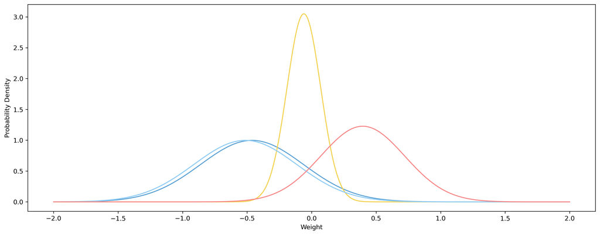

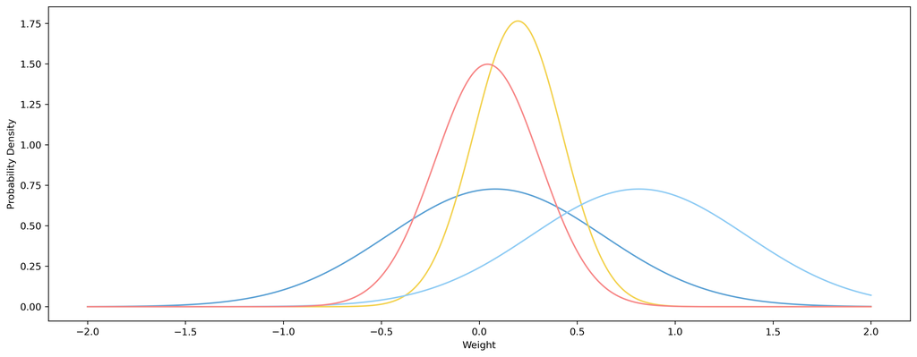

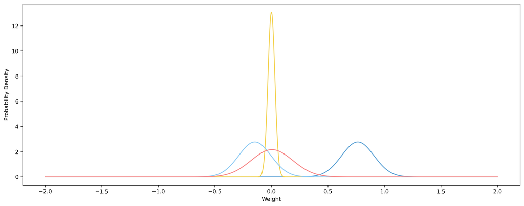

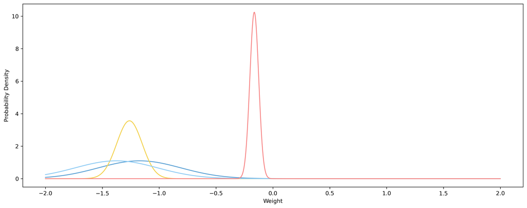

```python
for group in groups_1:
    plot_pds(group)
```

### Datatset 2

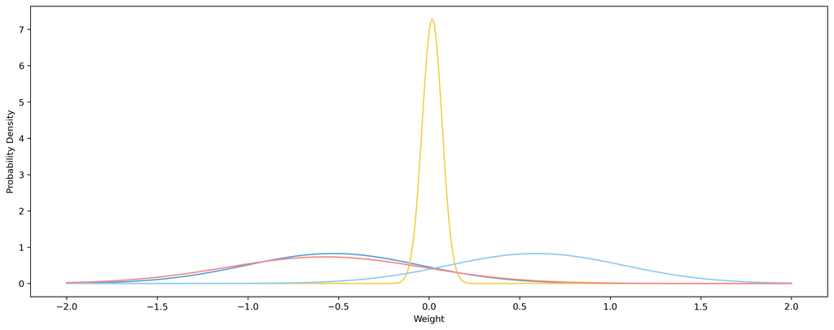

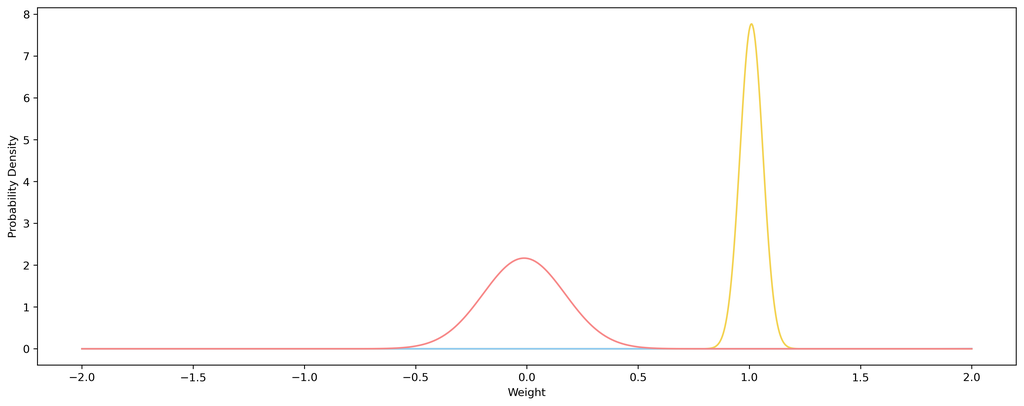

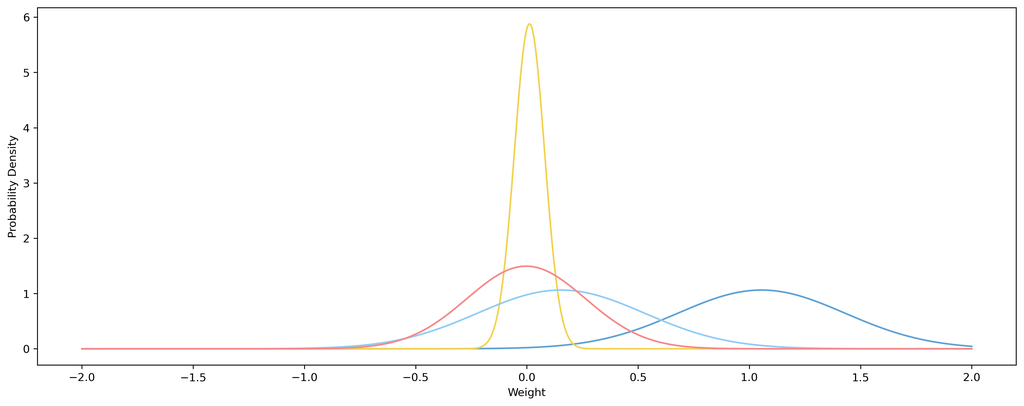

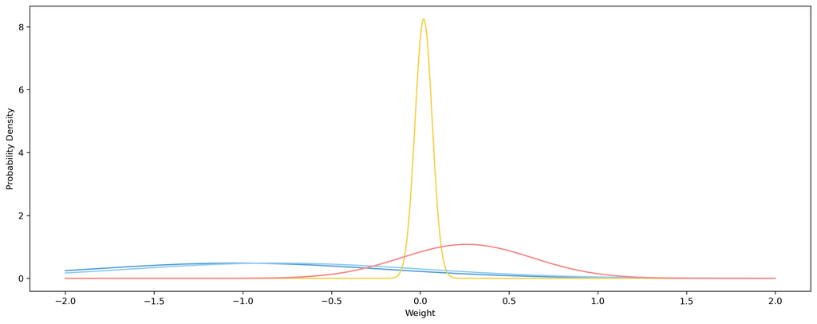

```python
for group in groups_2:
    plot_pds(group)
```

### Dataset 3

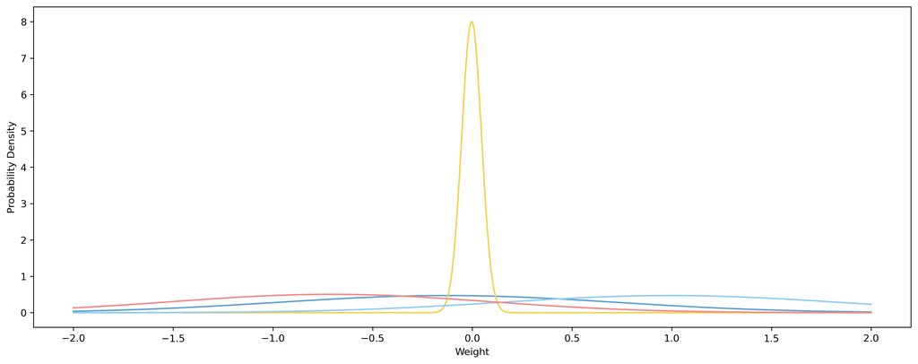

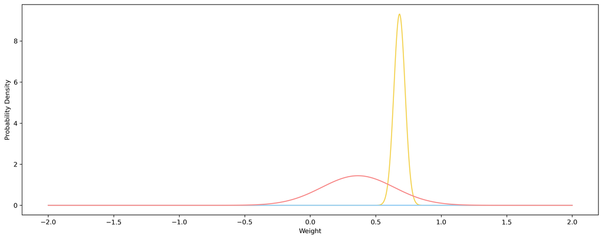

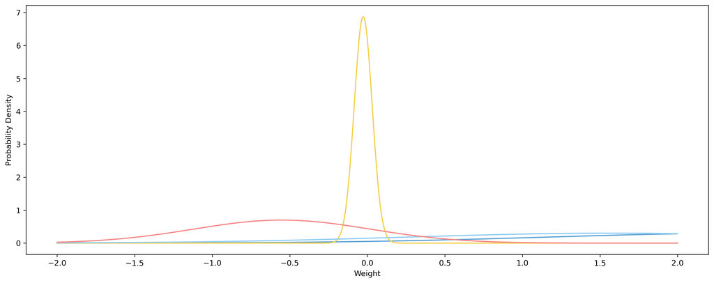

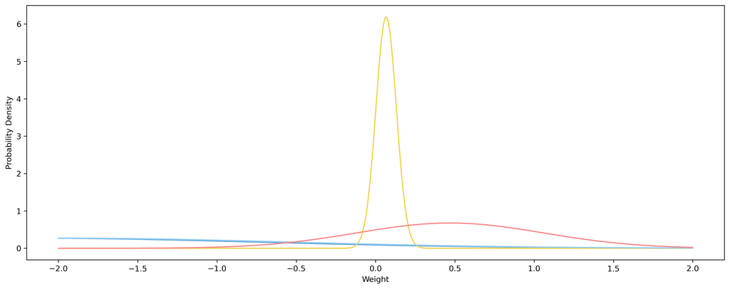

```python
for group in groups_3:
    plot_pds(group)
```

## Ranking Feature Importance

```python
def get_props(group):
    domain = np.linspace(-2,2,1000)
    means = [mean(group[i]) for i in range(len(group))]
    stds = [stdev(group[i]) for i in range(len(group))]
    results = []
    for mu, std in zip(means, stds):
        values = []
        probs = norm.pdf(domain, mu, std)
        for prob in probs:
            if math.floor(prob) != 0:
                values.append(prob)
        results.append(values)
    return results
```

```python
def barrage(all_probs, nodes: int):
    res = {
        i: {"len": 0, "max": 0, "sum": 0, "mean": 0, "stdev": 0} for i in range(nodes)
    }
    for probs in all_probs:
        for i, prob in enumerate(probs):
            try:
                res[i]["len"] += len(prob)
            except ValueError:
                pass
            try:
                res[i]["max"] += max(prob)
            except ValueError:
                pass
            try:
                res[i]["sum"] += sum(prob)
            except ValueError:
                pass
            try:
                res[i]["mean"] += mean(prob)
            except ValueError:
                pass
            try:
                res[i]["stdev"] += stdev(prob)
            except ValueError:
                pass
    return res
```

```python
def plot_barrage(method: str):
    cdict = {"ms": light, "xs": important, "cs": darker, "noises": noise}
    data = pd.Series(df.loc[method], df.columns).sort_values(ascending=True)
    cmap = [cdict[i] for i in list(data.index.values)]
    ax = data.plot.barh(width=0.8, figsize=(3, 1), color=cmap)
    ax.set_ylabel("Input")
    ax.set_xlabel(method.capitalize())
```

```python
all_probs_1 = [get_props(group) for group in groups_1]
all_probs_2 = [get_props(group) for group in groups_2]
all_probs_3 = [get_props(group) for group in groups_3]
```

### Dataset 1

```python
columns = ["ms", "xs", "cs", "noises"]

res = barrage(all_probs_1, len(columns))
for i in range(len(columns)):
    res[columns[i]] = res.pop(i)
df = pd.DataFrame(res)
df
```

|  | ms | xs | cs | noises |
| --- | --- | --- | --- | --- |
| len | 181.000000 | 342.000000 | 182.000000 | 380.000000 |
| max | 3.872808 | 21.461658 | 3.873023 | 15.134495 |
| sum | 295.065659 | 860.532093 | 296.067736 | 715.620298 |
| mean | 3.133169 | 13.325929 | 3.122827 | 9.945504 |
| stdev | 0.592871 | 5.884634 | 0.599854 | 3.756841 |

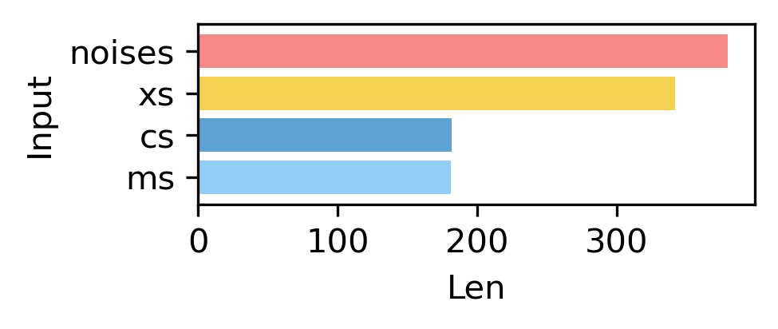

```python
plot_barrage("len")
```

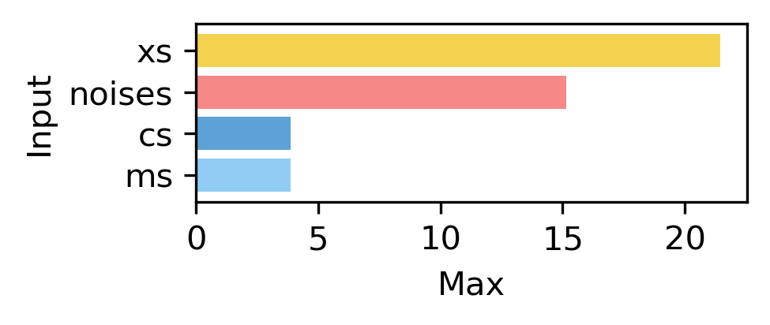

```python
plot_barrage("max")
```

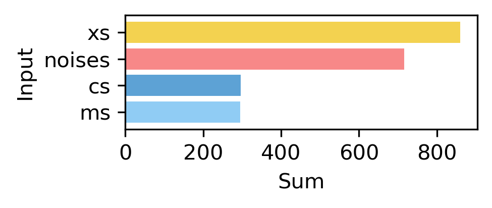

```python
plot_barrage("sum")
```

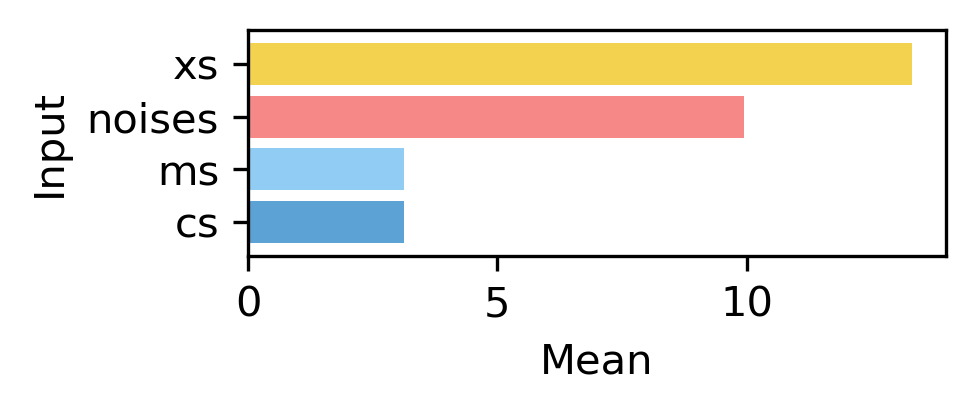

```python
plot_barrage("mean")
```

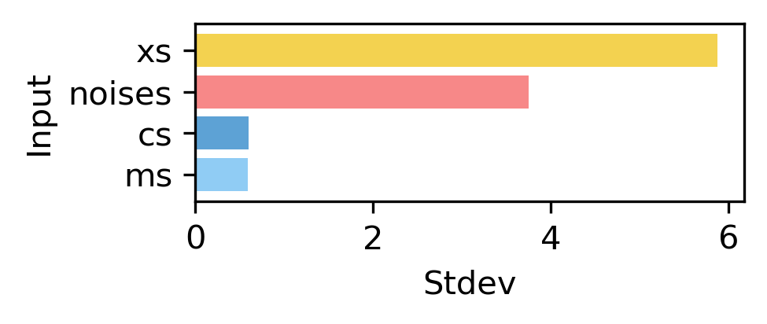

```python
plot_barrage("stdev")
```

### Dataset 2

```python
columns = ["ms", "xs", "cs", "noises"]

res = barrage(all_probs_2, len(columns))
for i in range(len(columns)):
    res[columns[i]] = res.pop(i)
df = pd.DataFrame(res)
df
```

|  | ms | xs | cs | noises |
| --- | --- | --- | --- | --- |
| len | 65.000000 | 220.000000 | 65.000000 | 307.000000 |
| max | 1.062569 | 29.166059 | 1.062570 | 4.741963 |
| sum | 67.709010 | 951.882345 | 67.709092 | 430.707714 |
| mean | 1.041677 | 17.489200 | 1.041678 | 4.087440 |
| stdev | 0.018681 | 8.473371 | 0.018683 | 0.544059 |

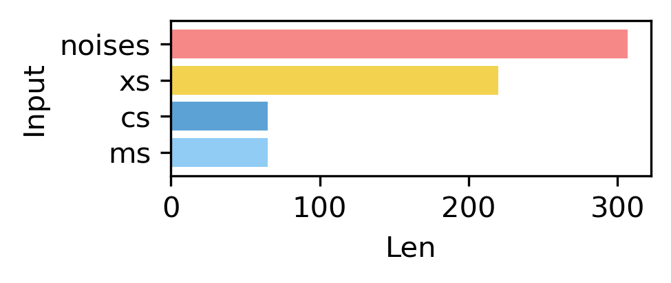

```python
plot_barrage("len")
```

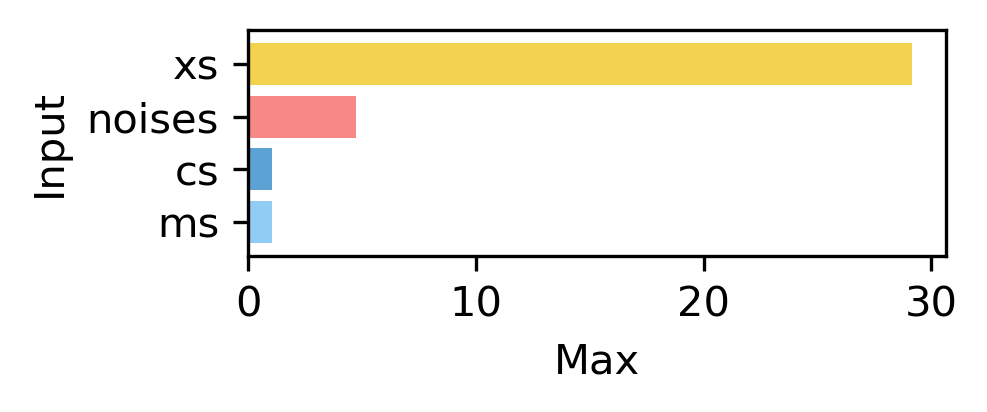

```python
plot_barrage("max")
```

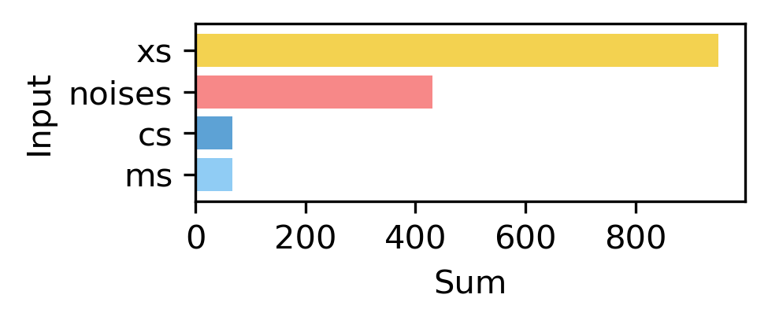

```python
plot_barrage("sum")
```

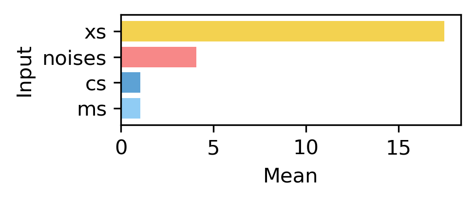

```python
plot_barrage("mean")
```

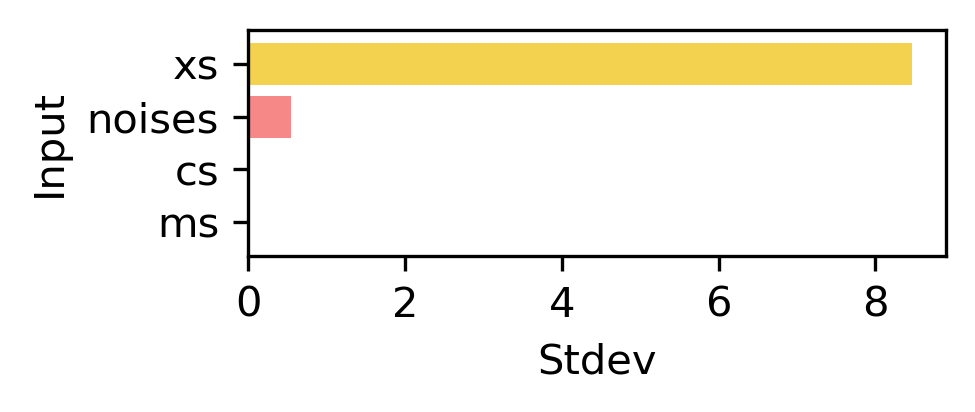

```python
plot_barrage("stdev")
```

### Dataset 3

```python
columns = ["ms", "xs", "cs", "noises"]

res = barrage(all_probs_3, len(columns))
for i in range(len(columns)):
    res[columns[i]] = res.pop(i)
df = pd.DataFrame(res)
df
```

|  | ms | xs | cs | noises |
| --- | --- | --- | --- | --- |
| len | 0 | 214.000000 | 0 | 118.000000 |
| max | 0 | 30.380154 | 0 | 1.440344 |
| sum | 0 | 953.251200 | 0 | 151.425022 |
| mean | 0 | 18.074763 | 0 | 1.283263 |
| stdev | 0 | 8.896426 | 0 | 0.134833 |

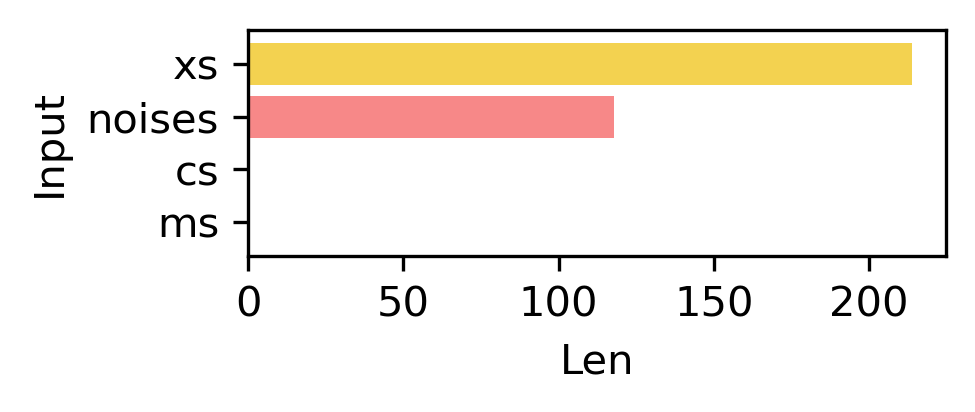

```python
plot_barrage("len")
```

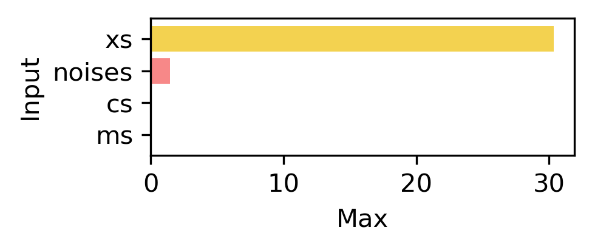

```python
plot_barrage("max")
```

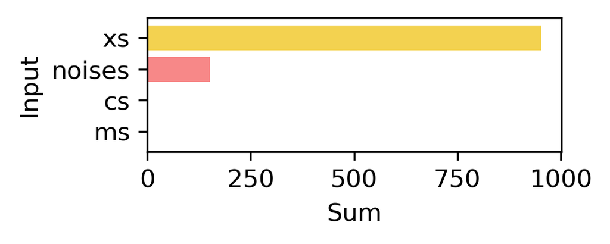

```python
plot_barrage("sum")
```

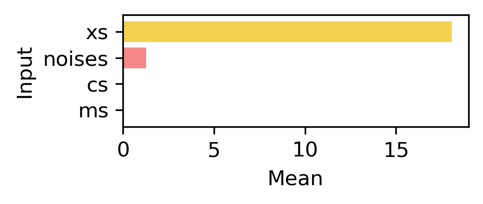

```python
plot_barrage("mean")
```

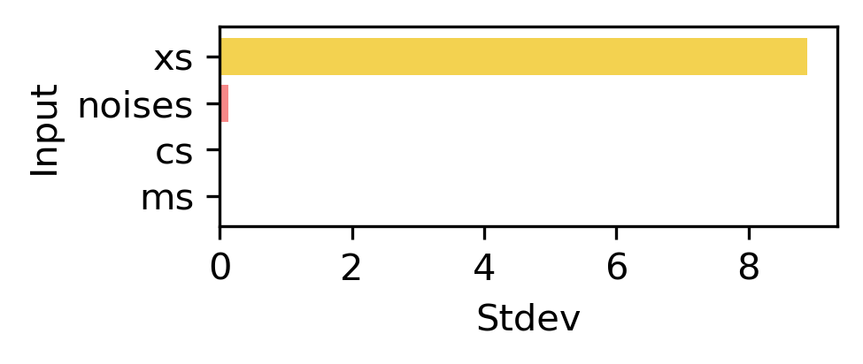

```python
plot_barrage("stdev")
```